| title:“P8105 Homework 3” |
| --- |
| author:“Kamiah Brown” |
| data:2024-10-16 |
| output:github_document |

```r
options(repos = c(CRAN = "https://cloud.r-project.org"))
```

```r
install.packages(
  c("tidyverse", "knitr", "rmarkdown", "janitor", "broom", "here", "readxl", "haven", "rnoaa", "ggridges", "ggthemes", "leaflet", "viridis", "skimr","rvest", "httr", "flexdashboard", "devtools", "usethis", "modelr", "mgcv","tidytext", "shiny", "patchwork", "glmnet", "plotly"))
```

```
##
##  /var/folders/6d/23nkgmz16w18rhzc_yms50g00000gn/T//RtmpFPrPE7/downloaded_packages
```

```r
remotes::install_github("p8105/p8105.datasets")
remotes::install_github("ropensci/rnoaa")
```

#Set up

```r
library(tidyverse)
library(ggridges)
library(haven)
library(knitr)
library(dplyr)
library(lubridate)
library(tidyr)
library(janitor)
```

```r
library(ggplot2)
library(readr)
```

#Problem 1

```r
library(p8105.datasets)
data("ny_noaa")
```

```r
str(ny_noaa)
```

```
## tibble [2,595,176 × 7] (S3: tbl_df/tbl/data.frame)
##  $ id  : chr [1:2595176] "US1NYAB0001" "US1NYAB0001" "US1NYAB0001" "US1NYAB0001" ...
##  $ date: Date[1:2595176], format: "2007-11-01" "2007-11-02" ...
##  $ prcp: int [1:2595176] NA NA NA NA NA NA NA NA NA NA ...
##  $ snow: int [1:2595176] NA NA NA NA NA NA NA NA NA NA ...
##  $ snwd: int [1:2595176] NA NA NA NA NA NA NA NA NA NA ...
##  $ tmax: chr [1:2595176] NA NA NA NA ...
##  $ tmin: chr [1:2595176] NA NA NA NA ...
##  - attr(*, "spec")=
##   .. cols(
##   ..   id = col_character(),
##   ..   date = col_date(format = ""),
##   ..   prcp = col_integer(),
##   ..   snow = col_integer(),
##   ..   snwd = col_integer(),
##   ..   tmax = col_character(),
##   ..   tmin = col_character()
##   .. )
```

```r
head(ny_noaa)
```

```
## # A tibble: 6 × 7
##   id          date        prcp  snow  snwd tmax  tmin
##   <chr>       <date>     <int> <int> <int> <chr> <chr>
## 1 US1NYAB0001 2007-11-01    NA    NA    NA <NA>  <NA>
## 2 US1NYAB0001 2007-11-02    NA    NA    NA <NA>  <NA>
## 3 US1NYAB0001 2007-11-03    NA    NA    NA <NA>  <NA>
## 4 US1NYAB0001 2007-11-04    NA    NA    NA <NA>  <NA>
## 5 US1NYAB0001 2007-11-05    NA    NA    NA <NA>  <NA>
## 6 US1NYAB0001 2007-11-06    NA    NA    NA <NA>  <NA>
```

```r
ny_noaa_cleaned <- ny_noaa |>
  clean_names() |>
  mutate(
    year = year(date),
    month = month(date),
    day = day(date),
    tmax = as.numeric(tmax),
    tmin = as.numeric(tmin),
    prcp = as.numeric(prcp),
    snow = as.numeric(snow)
  ) |>
  mutate(
    tmax = tmax / 10,
    tmin = tmin / 10,
    prcp = prcp / 10,
    snow = snow / 10
  ) |>
  drop_na() |>
  distinct()

head(ny_noaa_cleaned)
```

```
## # A tibble: 6 × 10
##   id          date        prcp  snow  snwd  tmax  tmin  year month   day
##   <chr>       <date>     <dbl> <dbl> <int> <dbl> <dbl> <dbl> <dbl> <int>
## 1 USC00300023 1981-01-03     0     0     0 -12.2 -20.6  1981     1     3
## 2 USC00300023 1981-01-05     0     0     0  -5.6 -17.8  1981     1     5
## 3 USC00300023 1981-01-12     0     0     0 -12.2 -30.6  1981     1    12
## 4 USC00300023 1981-01-13     0     0     0  -6.7 -28.9  1981     1    13
## 5 USC00300023 1981-01-15     0     0     0  -5   -10.6  1981     1    15
## 6 USC00300023 1981-01-17     0     0     0  -1.1 -15    1981     1    17
```

```r
summary(ny_noaa_cleaned[, c("tmax", "tmin", "prcp", "snow")])
```

```
##       tmax             tmin              prcp               snow
##  Min.   :-38.90   Min.   :-58.300   Min.   :   0.000   Min.   : -1.3000
##  1st Qu.:  5.60   1st Qu.: -2.800   1st Qu.:   0.000   1st Qu.:  0.0000
##  Median : 16.10   Median :  4.400   Median :   0.000   Median :  0.0000
##  Mean   : 14.65   Mean   :  3.625   Mean   :   3.008   Mean   :  0.4649
##  3rd Qu.: 23.90   3rd Qu.: 11.700   3rd Qu.:   2.300   3rd Qu.:  0.0000
##  Max.   : 44.40   Max.   : 37.200   Max.   :2032.500   Max.   :776.5000
```

```r
snowfall_freq <- table(ny_noaa_cleaned$snow)
snowfall_freq_q1 <- sort(snowfall_freq, decreasing = TRUE)

head(snowfall_freq_q1)
```

```
##
##       0     2.5     1.3     5.1     0.5     0.8
## 1112758   15809   12460    9252    5669    5380
```

The commonly observed snowfall value is 0 as it appears 1,112,758 times. Its common to have no snowfall considering some areas may havwe warmer climates or warmer seasons where snow is rare/ not common.

#Two Panel Plots

```r
janjul_data <- ny_noaa_cleaned |>
  filter(month == 1 | month == 7) |>
  group_by(id, year, month) |>
  summarize(avg_tmax = mean(tmax, na.rm = TRUE))
```

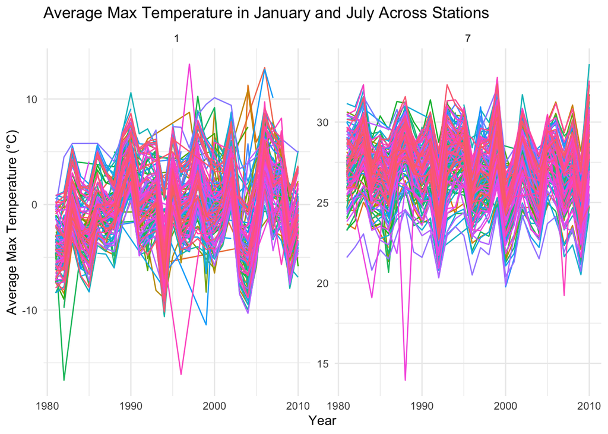

```r
ggplot(janjul_data, aes(x = year, y = avg_tmax, color = as.factor(id))) +
  geom_line() +
  facet_wrap(~ month, scales = "free_y") +
  labs(title = "Average Max Temperature in January and July Across Stations",
       x = "Year", y = "Average Max Temperature (°C)", color = "Station ID") +
  theme_minimal() +
  theme(legend.position = "none")
```

The left panel shows the average max temp for January from 1980 to 2010. Most of the stations appear to range between -10 and 10 C. After 2000, the temp seems to increase compared to before 2000. There are a few outliers where the temp is between -15 and -20. These stations might be located in colder regions. January has more variablity as well compared to July.

#Panel 1: tmax vs tmin for the full dataset

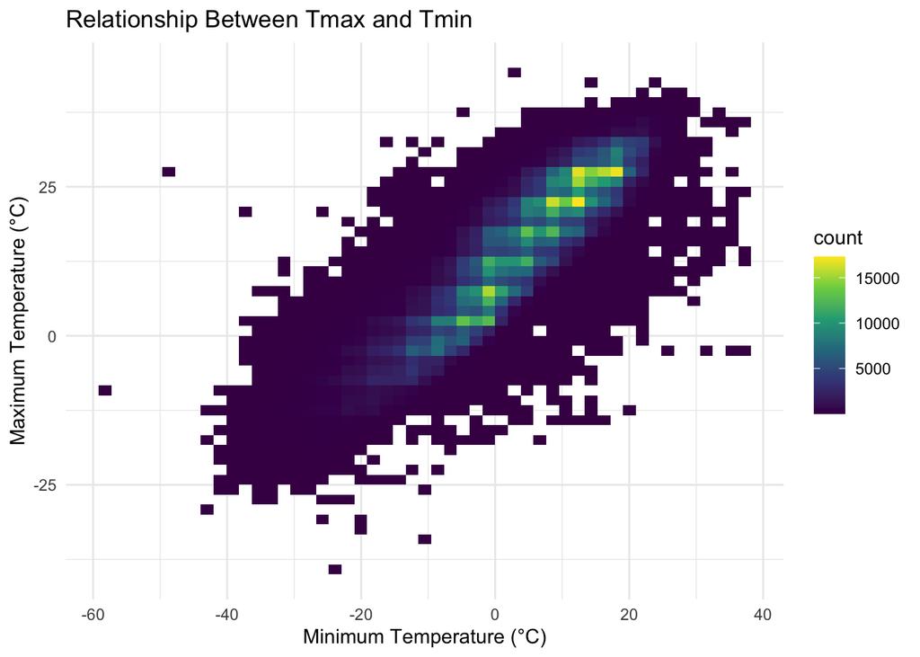

```r
ggplot(ny_noaa_cleaned, aes(x = tmin, y = tmax)) +
  geom_bin2d(bins = 50) +
  scale_fill_viridis_c() +
  labs(
    x = "Minimum Temperature (°C)",
    y = "Maximum Temperature (°C)",
    title = "Relationship Between Tmax and Tmin"
  ) +
  theme_minimal()
```

#Panel 2:distribution of snowfall values greater than 0 and less than 100 separately by year

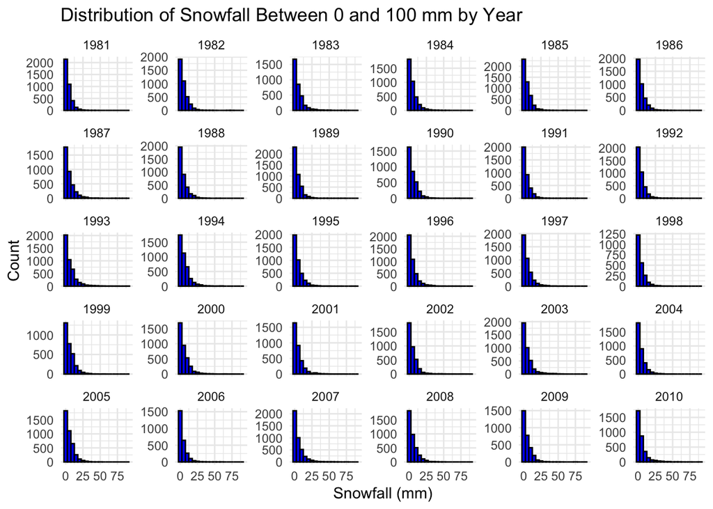

```r
snowfall <- ny_noaa_cleaned |>
  filter(snow > 0 & snow < 100)

ggplot(snowfall, aes(x = snow)) +
  geom_histogram(binwidth = 5, fill = "blue", color = "black") +
  facet_wrap(~ year, scales = "free_y") +
  labs(
    x = "Snowfall (mm)",
    y = "Count",
    title = "Distribution of Snowfall Between 0 and 100 mm by Year"
  ) +
  theme_minimal()
```

#problem 2

```r
demographic_data <- read_csv('nhanes_covar.csv', skip = 1, col_names = c("SEQN", "sex", "age", "BMI", "education"))
accelerometer_data <- read_csv('nhanes_accel.csv')
colnames(demographic_data)
```

```
## [1] "SEQN"      "sex"       "age"       "BMI"       "education"
```

```r
demographic_data_clean <- demographic_data |>
  mutate(
    age = as.numeric(age),
    BMI = as.numeric(BMI),
    sex = factor(sex, levels = c("1", "2"), labels = c("Male", "Female")),
    education = factor(education, levels = c("1", "2", "3"), labels = c("Less than high school", "High school", "Some college"))
  ) |>
  filter(age >= 21) |>
  drop_na()
str(demographic_data_clean)
```

```
## tibble [228 × 5] (S3: tbl_df/tbl/data.frame)
##  $ SEQN     : chr [1:228] "62161" "62164" "62169" "62174" ...
##  $ sex      : Factor w/ 2 levels "Male","Female": 1 2 1 1 1 1 1 1 2 1 ...
##  $ age      : num [1:228] 22 44 21 80 51 80 35 26 30 57 ...
##  $ BMI      : num [1:228] 23.3 23.2 20.1 33.9 20.1 28.5 27.9 22.1 22.4 28 ...
##  $ education: Factor w/ 3 levels "Less than high school",..: 2 3 2 3 2 2 3 2 3 3 ...
```

```r
education_gender_table <- demographic_data_clean |>
  group_by(education, sex) |>
  summarise(count = n()) |>
  ungroup()
```

#Create table

```r
gender_education_table <- table(demographic_data_clean$education, demographic_data_clean$sex)

gender_education_table
```

```
##
##                         Male Female
##   Less than high school   27     28
##   High school             35     23
##   Some college            56     59
```

There is no gender difference among those who have less than high school education as there are 27 men and 28 women. There are more men than women with a high school education (35 v 23). There are more women with some college compared to men (59 v.56). The high school category has a greater difference compared to the ‘high school’ and ‘some college’ category.

#Create visualization

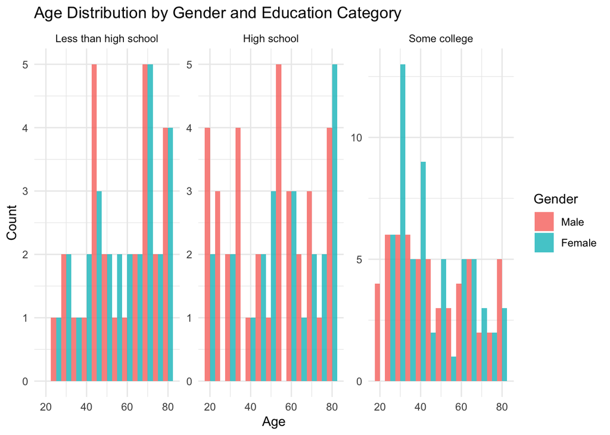

```r
ggplot(demographic_data_clean, aes(x = age, fill = sex)) +
  geom_histogram(binwidth = 5, position = "dodge", alpha = 0.8) +
  facet_wrap(~ education, scales = "free_y") +
  labs(
    title = "Age Distribution by Gender and Education Category",
    x = "Age",
    y = "Count",
    fill = "Gender"
  ) +
  theme_minimal()
```

The graph shows the age distribution by gender and education level, categorized into ‘less than high school,’ ‘high school,’ and ‘some college.’ Among those with less than a high school education, the graph reveals that a significant portion of individuals fall in the 60-80 age range, indicating that older individuals are more likely to have less formal education. However, there is also a notable presence of individuals in the 40-60 age group. This suggests that lower education levels are more common among older generations, potentially reflecting historical trends where fewer individuals had access to or pursued higher education. The smaller number of younger individuals in this category suggests that younger generations are receiving higher levels of education, likely due to increased scholastic opportunities and societal changes that promotes education. In the high school category, there are noticeable peaks in the 40-60 age group, suggesting that high school completion is a common level of education across a wide range of ages. Men tend to be more represented in the younger age groups (ages 20-40) compared to women, indicating that younger men are more likely to complete high school compared to their women counterparts. However, in the 70-80 age group, women surpass men, which may reflect historical trends where women returned to education later in life. This difference between genders in the older age group suggests that women in past generations may have had fewer opportunities for early education but returned later to complete their high school education (also displayed in the ‘less than high school’. Lastly, in the some college category, the graph shows a significant concentration of younger individuals, particularly women in the 20-40 age range. This implies that there has been a shift in pursuing higher education beyond high school, especially among younger generations. Women, in particular, are more likely to pursue “some college” education early in life, suggesting that societal trends have shifted towards encouraging women to seek higher education opportunities at younger ages.

#data cleaning

```r
accelerometer_long <- accelerometer_data |>
  pivot_longer(
    cols = starts_with("min"),
    names_to = "minute",
    values_to = "MIMS"
  )

accelerometer_long <- accelerometer_long |>
  mutate(minute = as.numeric(gsub("min", "", minute)))

total_activity_data <- accelerometer_long |>
  group_by(SEQN, minute) |>
  summarise(MIMS = sum(MIMS, na.rm = TRUE))
```

```r
total_activity_data <- total_activity_data |>
  mutate(SEQN = as.character(SEQN))

demographic_data_clean <- demographic_data_clean |>
  mutate(SEQN = as.character(SEQN))

final_data <- total_activity_data |>
  left_join(demographic_data_clean, by = "SEQN")

final_data_clean <- final_data |>
  filter(
    !is.na(MIMS) & !is.na(age) & !is.na(sex) &
    !is.infinite(MIMS) & !is.infinite(age)
  )

head(final_data_clean)
```

```
## # A tibble: 6 × 7
## # Groups:   SEQN [1]
##   SEQN  minute  MIMS sex     age   BMI education
##   <chr>  <dbl> <dbl> <fct> <dbl> <dbl> <fct>
## 1 62161      1 1.11  Male     22  23.3 High school
## 2 62161      2 3.12  Male     22  23.3 High school
## 3 62161      3 1.47  Male     22  23.3 High school
## 4 62161      4 0.938 Male     22  23.3 High school
## 5 62161      5 1.60  Male     22  23.3 High school
## 6 62161      6 0.145 Male     22  23.3 High school
```

#plotting activities

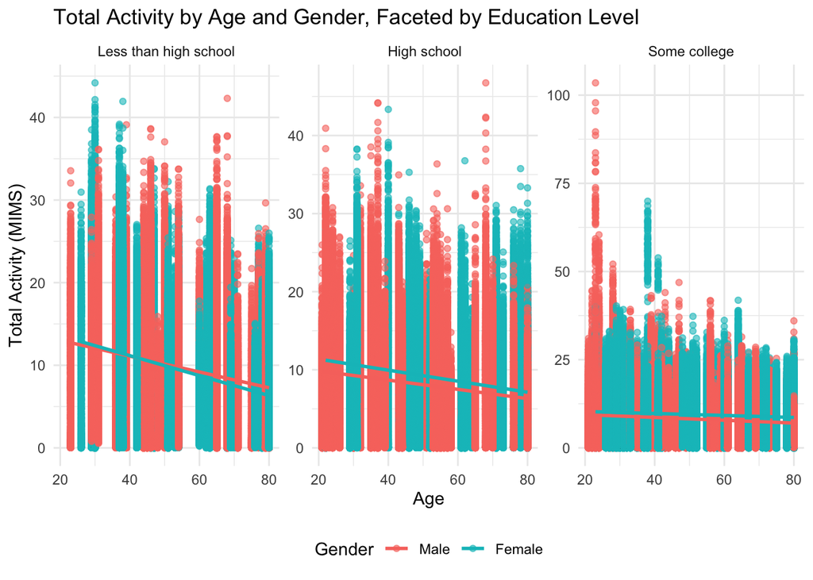

```r
ggplot(final_data_clean, aes(x = age, y = MIMS, color = sex)) +
  geom_point(alpha = 0.6) +
  geom_smooth(method = "lm", se = FALSE) +
  facet_wrap(~ education, scales = "free_y") +
  labs(
    title = "Total Activity by Age and Gender, Faceted by Education Level",
    x = "Age",
    y = "Total Activity (MIMS)",
    color = "Gender"
  ) +
  theme_minimal() +
  theme(legend.position = "bottom")
```

In less than high school, men and women have similar activity levels when they are younger (20-40), but as they age, women’s activity tends to be lower than men. There tends to be a decline in activity as age increase, particularly among men which shows that men and women become less physically active as their age increase.

In high school, women with a high school education tend to be more active with a gradual decline afterwards. Overall, women with a high school education tend to be more active than men. Men tend to be less active and also have a less noticeable decline in activity compared to women.

For some college, activity levels tend to remain stable across ages among women and men. There tends to be more consistent activity, but women are more likely to be active than men in this category. This also shows that unlike those with a ‘less than high school’ and ‘high school’ education, those with ‘some college’ education are consistently active throughout their life.

#Problem 2 three-panel plot that shows the 24-hour activity time courses for each education level and use color to indicate sex

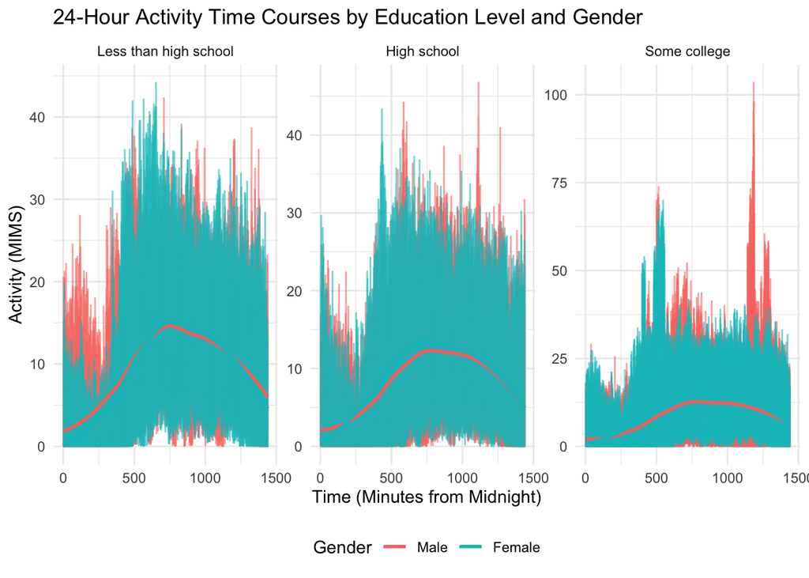

```r
accelerometer_long <- accelerometer_data |>
  pivot_longer(cols = starts_with("min"),
               names_to = "minute",
               values_to = "MIMS")

accelerometer_long <- accelerometer_long |>
  mutate(minute = as.numeric(gsub("min", "", minute)))

accelerometer_long <- accelerometer_long |>
  mutate(SEQN = as.character(SEQN))

demographic_data_clean <- demographic_data_clean |>
  mutate(SEQN = as.character(SEQN))

final_data <- accelerometer_long |>
  left_join(demographic_data_clean, by = "SEQN")

#Plot
ggplot(final_data_clean, aes(x = minute, y = MIMS, color = sex)) +
  geom_line(alpha = 0.6) +
  geom_smooth(method = "loess", se = FALSE) +
  facet_wrap(~ education, scales = "free_y") +
  labs(
    title = "24-Hour Activity Time Courses by Education Level and Gender",
    x = "Time (Minutes from Midnight)",
    y = "Activity (MIMS)",
    color = "Gender"
  ) +
  theme_minimal() +
  theme(legend.position = "bottom")
```

#problem 3

```r
jan_2020 <- read_csv("Jan 2020 Citi.csv")
jan_2024 <- read_csv("Jan 2024 Citi.csv")
july_2020 <- read_csv("July 2020 Citi.csv")
july_2024 <- read_csv("July 2024 Citi.csv")
jan_2020 <- jan_2020 |>
  mutate(year = 2020, month = "January")

july_2020 <- july_2020 |>
  mutate(year = 2020, month = "July")

jan_2024 <- jan_2024 |>
  mutate(year = 2024, month = "January")

july_2024 <- july_2024 |>
  mutate(year = 2024, month = "July")

citibikes <- bind_rows(jan_2020, jan_2024, july_2020, july_2024)

#Clean data after merging
citibikes_cleaned <- citibikes |>
  clean_names() |>
  drop_na() |>
  filter(duration < 240 * 60) |>
  distinct()

summary(citibikes_cleaned)
```

```
##    ride_id          rideable_type        weekdays            duration
##  Length:99253       Length:99253       Length:99253       Min.   :  1.002
##  Class :character   Class :character   Class :character   1st Qu.:  5.587
##  Mode  :character   Mode  :character   Mode  :character   Median :  9.823
##                                                           Mean   : 13.836
##                                                           3rd Qu.: 17.515
##                                                           Max.   :238.780
##  start_station_name end_station_name   member_casual           year
##  Length:99253       Length:99253       Length:99253       Min.   :2020
##  Class :character   Class :character   Class :character   1st Qu.:2020
##  Mode  :character   Mode  :character   Mode  :character   Median :2024
##                                                           Mean   :2023
##                                                           3rd Qu.:2024
##                                                           Max.   :2024
##     month
##  Length:99253
##  Class :character
##  Mode  :character
##
##
##
```

The cleaned citibike dataset contains 99,253 rides, with the average ride duration being 13.8. The longest recorded ride duration was 238.780 minutes. The minimum duration was 1 minute.

#the total number of rides in each combination of year and month separating casual riders and Citi Bike members.

```r
ride_summary <- citibikes_cleaned |>
  group_by(year, month, member_casual) |>
  summarise(total_rides = n(), .groups = "drop") |>
  arrange(year, month)

# Print the summary table
print(ride_summary)
```

```
## # A tibble: 8 × 4
##    year month   member_casual total_rides
##   <dbl> <chr>   <chr>               <int>
## 1  2020 January casual                980
## 2  2020 January member              11418
## 3  2020 July    casual               5625
## 4  2020 July    member              15388
## 5  2024 January casual               2094
## 6  2024 January member              16705
## 7  2024 July    casual              10843
## 8  2024 July    member              36200
```

There is an increase of rides from 2020 to 2024 with from both casual and citibike members. Compared to January, more people ride more in July, which could indicate the seasonal change influencing ridership. Citibike members are more likely to ride more than casual members across both years and months which is expected since they are citibike members. Additionally, the number of casual rides nearly doubles in July between 2020 (5,625) and 2024 (10,843), indicating an growing interest among non-members potentially, driven by popularity after the COVID-19 pandemic.

#Table showing 5 most popular stations for July 2024

```r
stations_july_2024 <- citibikes_cleaned |>
  filter(year == 2024 & month == "July") |>
  group_by(start_station_name) |>
  summarise(total_rides = n()) |>
  arrange(desc(total_rides)) |>
  slice_max(order_by = total_rides, n = 5)

print(stations_july_2024)
```

```
## # A tibble: 5 × 2
##   start_station_name       total_rides
##   <chr>                          <int>
## 1 Pier 61 at Chelsea Piers         163
## 2 University Pl & E 14 St          155
## 3 W 21 St & 6 Ave                  152
## 4 West St & Chambers St            150
## 5 W 31 St & 7 Ave                  145
```

#The top 5 most popular stations are Pier 61 at Chelsea Piers with 163 rides, University Pl & E 14 st with 155 rides, W 21 st & 6 Ave with 152 rides, West St & Chambers with 150 rides and W 31st and 7th ave with 145 rides.

#Median ride duration

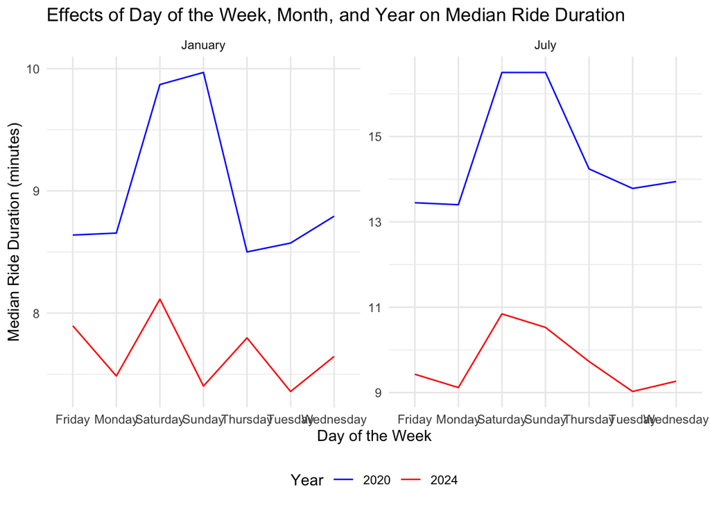

```r
median_duration_data <- citibikes_cleaned |>
  group_by(year, month, weekdays) |>
  summarise(median_duration = median(duration, na.rm = TRUE), .groups = "drop")

# Create the plot using ggplot2
median_duration_plot <- ggplot(median_duration_data, aes(x = weekdays, y = median_duration, color = factor(year))) +
  geom_line(aes(group = interaction(month, year))) +
  facet_wrap(~ month, scales = "free_y") +
  labs(
    title = "Effects of Day of the Week, Month, and Year on Median Ride Duration",
    x = "Day of the Week",
    y = "Median Ride Duration (minutes)",
    color = "Year"
  ) +
  theme_minimal() +
  theme(legend.position = "bottom") +
  scale_color_manual(values = c("2020" = "blue", "2024" = "red"))

# Print the plot
print(median_duration_plot)
```

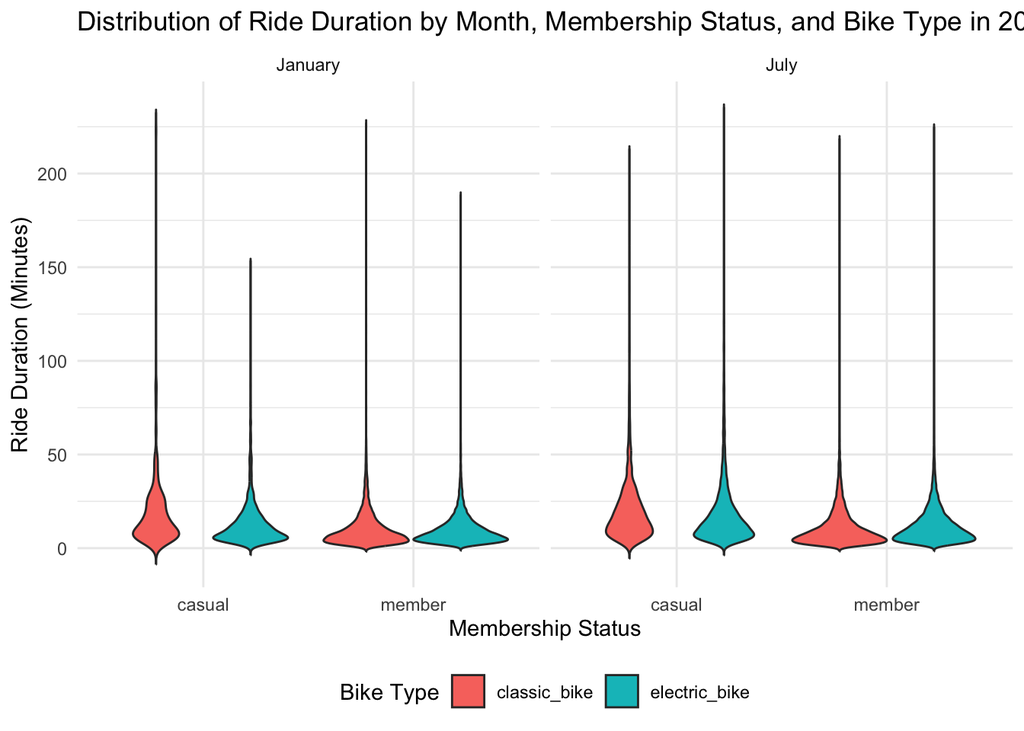

```r
citibike_2024 <- citibikes_cleaned |>
  filter(year == "2024")

#Graphing
ggplot(citibike_2024, aes(x = member_casual, y = duration, fill = rideable_type)) +
  geom_violin(trim = FALSE) +
  facet_wrap(~ month) +
  labs(
    title = "Distribution of Ride Duration by Month, Membership Status, and Bike Type in 2024",
    x = "Membership Status",
    y = "Ride Duration (Minutes)",
    fill = "Bike Type"
  ) +
  theme_minimal() +
  theme(legend.position = "bottom")
```